# Part 3

Jane Huber

3/3/2022

# 1 Introduction (Part A)

Homes in Detroit have suffered from poorly assessed home values, which has contributed greatly to foreclosure during a time of economic instability. The UC Irvine Law Review’s [“Taxed Out: Illegal Property Tax Assessments and the Epidemic of Tax Foreclosures in Detroit”](https://scholarship.law.uci.edu/ucilr/vol9/iss4/3/) analyzes the relationship between over-assessing a home and its role in driving foreclosures, exposing government’s role in creating conditions for people to lose their homes. The Harris School of Public Policy at the University of Chicago’s The Center For Municipal Finance produced the report [“An Evaluation of Residential Property Tax Assessments in the City of Detroit, 2016-2018”](https://harris.uchicago.edu/files/evalrespropertytaxasdetroit20162018.pdf) shows how the city of Detroit attempted to correct that mistake, reducing the number of assessments higher than sales, but that it’s still too high.

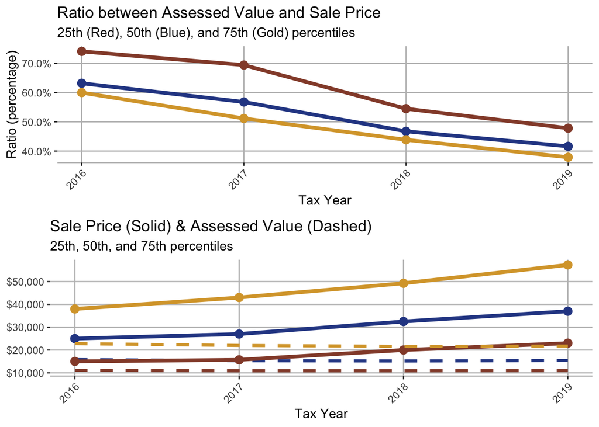

# 2 Additional Predictors Impact On Models (Part B)

When evaluating over-assessments for homes in Detroit, using 2016 as a year to generate a model predicting the likelihood of over-assessments, we test a base model that evaluates the impact of ward, sale price, zip code, and the total square footage of a home. Then, we compare the results by adding in more nuanced predictors, such as the percent of home foreclosures in a zip code and the average sale price of a home in the zip code. Interestingly, adding in these more nuanced variables made a less effective model; this may suggest that the initial model slightly overfit or that there is an interaction here that we do not understand.

| measurement | initial_model | with_additional_values |
| --- | --- | --- |
| true positive rate | 0.2119914 | 0.1951754 |
| true negative rate | 0.1026856 | 0.1242038 |
| false positive rate | 0.8973144 | 0.8757962 |
| false negative rate | 0.7880086 | 0.8048246 |
| positive predictive value | 0.1484258 | 0.1392801 |

Stepping into the shoes of the assessor in Detroit, we also develop a model to predict sale prices of homes in Detroit, which could be used to inform assessments. By evaluating and testing on sales in the city of Detroit in 2019, we can train our model based on sales and see if we are able to effectively predict sale prices for other homes in Detroit. We follow our strategy for over-assessments, generating a base model that looks at ward, zip code, total square footage, and assessed_value. We then augment this model with the percent of home foreclosures in a zip code and the average sale price of a home in the zip code to see if it improves our model. Unlike the over-assessments, this helped to improve our model.

| first_RMSE | second_RMSE |
| --- | --- |
| 30162.53 | 29083.43 |

The additional variables improve our model’s RMSE, but it is still relatively high and suggests we should continue to explore more effective predictors.

# 3 Out Of Sample Predictions (Part C)

## 3.1 Overassessments: Applying 2016 model to homes that did not sell

Next, let’s apply our over-assessment model to homes that were not sold in 2016, in an attempt to predict what homes would have been over-assessed in 2016 (i.e. we have no way to directly confirm whether our prediction is correct).

| overassessed | predicted_not_overassessed | predicted_overassessed |
| --- | --- | --- |
| YES | 38112 | 94696 |
| NO | 99248 | 14890 |
| NA | 17 | 5 |

# 4 Model Explanation (Part D)